# Che cos'è un campo?

Fisica · 4A — I CAMPI, T1

Prima lezione dell'anno · 2 h · venerdì 4 settembre

## Come si valuta quest'anno

| Strumento | Peso |
| --- | --- |
| Midterm test | 1 |
| Examination week test | 1 |
| Interrogazioni orali | 0,5 |
| Lab report e gruppo | 0,2 |
| Test formativi di fine unità | *feedback, non fa media* |

## Il ritmo della settimana

**LUN**

2 giorni

**MER**

5 giorni

**LUN**

Le consegne lunghe si assegnano di mercoledì.

## La mappa dell'anno: tre domande sui campi

T1

Come si descrive un campo?

T2

Da dove nasce un campo?

T3

Cosa implica prendere Maxwell sul serio?

## Un problema scomodo

?

La Terra attira la Luna a 380 000 km di distanza.  
Attraverso che cosa?

## Un campo modifica lo spazio

Un campo assegna a ogni punto dello spazio una grandezza,  
e si conosce solo attraverso la reazione di una sonda.

| Sonda | Risposta |
| --- | --- |
| carica di prova q | forza F |
| … | … |

## Quattro forze, un ordine sorprendente

Quali forze fondamentali dell'universo conosci?

Gravitazionale, elettromagnetica, nucleare forte, nucleare debole.

Mettile in ordine di intensità, dalla più alla meno forte.

## Forte, elettromagnetica, debole, gravitazionale

Eppure è la gravità a tenere insieme pianeti e galassie. Perché?

Sonda, caso elettrico

Piccola. Di valore noto. Abbastanza piccola da non alterare in modo apprezzabile il campo che sta sondando.

1785 — Coulomb misura per primo la forza fra due cariche, con una bilancia di torsione.

## Tolgo la sonda…

Se tolgo la carica di prova,  
che cosa resta in quel punto dello spazio?

Il campo NON è la forza.  
La forza esiste tra due oggetti; il campo è generato da uno solo.

## Più lontano, più debole

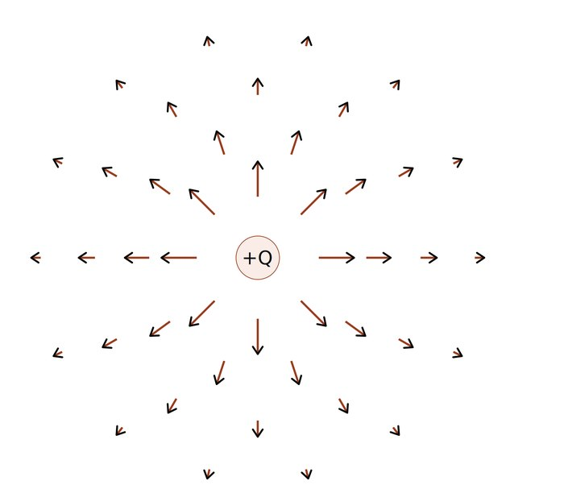

Cosa si nota?

La legge esatta (Coulomb) la vedremo il 7/09 — oggi basta la forma: più lontano, più debole.

## Campi vettoriali intorno a noi

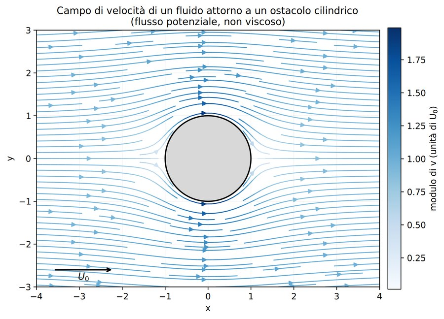

Più veloce ai lati dell'ostacolo, quasi fermo davanti e dietro. Le linee non si incrociano mai.

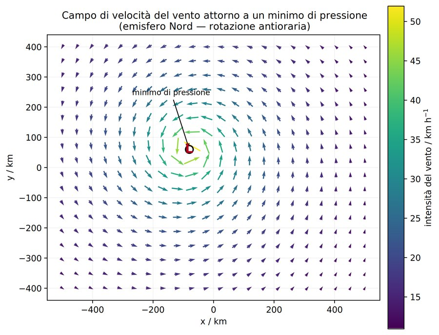

Il vento gira attorno al minimo di pressione.

## Il campo che fa muovere la bussola

[figure not shown]

Le linee sono sempre chiuse: nessun monopolo isolato.

## Quando la carica è troppa

⚡

La scintilla è l'aria che si "rompe" elettricamente.

## Elettrizzazione per induzione

−

+ + +

− − −

conduttore, nel complesso ancora neutro

Le cariche si separano, non si creano. Basta allontanare la bacchetta: torna tutto come prima.

## Elettrizzazione per contatto

−

− − −

carica netta, distribuita su tutto l'oggetto

Parte della carica passa davvero da un oggetto all'altro. Anche allontanando la bacchetta, la carica resta.

## Elettrizzazione per polarizzazione

−

+−+−+− +−+−+− +−+−+−

isolante: tanti piccoli dipoli allineati, nessuna carica libera si sposta

Il lato vicino, di segno opposto, è più vicino della bacchetta del lato lontano: l'oggetto resta neutro ma viene attirato.

## Tre modi, un confronto

| Meccanismo | Permanente? | Serve un conduttore? | Serve il contatto? |
| --- | --- | --- | --- |
| Induzione | No | Sì | No |
| Contatto | Sì | Sì | Sì |
| Polarizzazione | No | No | No |

Principio

In un sistema isolato, la carica elettrica totale non cambia.

conservation of charge

La bacchetta strofinata è positiva perché il panno è diventato negativo della stessa quantità. Non è un postulato: è verificabile.

Quiz formativo · Domanda 1 di 4

## Se tolgo la carica di prova da un punto dello spazio, il campo elettrico in quel punto:

1. Sparisce
2. Resta
3. Diventa nullo solo se non ci sono altre cariche
4. Non è definito

Il campo è generato dalla sorgente, non dalla sonda: esiste anche senza carica di prova nel punto.

Quiz formativo · Domanda 2 di 4

## Avvicino una bacchetta carica a un elettroscopio senza toccarlo. La carica totale dell'elettroscopio:

1. Aumenta
2. Diminuisce
3. Resta la stessa
4. Dipende dal segno della bacchetta

È induzione: le cariche si separano internamente, ma la carica totale dell'elettroscopio non cambia.

Quiz formativo · Domanda 3 di 4

## Due cariche puntiformi si respingono. Posso dire che:

1. Sono entrambe positive
2. Sono entrambe negative
3. Hanno lo stesso segno
4. Hanno segni opposti

La repulsione dice solo che il segno è uguale, non quale: potrebbero essere entrambe positive o entrambe negative.

Quiz formativo · Domanda 4 di 4

## Perché un elettroscopio carico si scarica se lo tocco con la mano?

1. La mano è isolante
2. Il corpo umano conduce e la carica si distribuisce fino a terra
3. La carica si annulla
4. L'aria la porta via

Il corpo umano è un conduttore collegato a terra: la carica si redistribuisce su una "massa" enormemente più grande, azzerando di fatto l'effetto misurabile.

## Cosa portiamo a casa

- Un campo non è una forza: assegna una grandezza a ogni punto dello spazio.
- Il campo ci dà informazioni su cosa succede a una sonda di prova posizionata in un determinato punto dello spazio.
- Lunedì: cariche, elettrizzazione, E = F/q, Legge di Coulomb.

"Knowledge isn't free. You have to pay attention." — Richard P. Feynman